# Project

Group 3

2025-04-19

# Cholesterol Project

```r
library(tidyverse)
```

```r
library(dplyr)
library(ggplot2)
library(leaps)
library(nortest)
library(car)
library(ggcorrplot)
library(gridExtra)
df<-read_csv("CHOLESTEROL.csv")
df
```

```
## # A tibble: 100 × 12
##    Weight Height Gender Heredity Smoke  Race  Diet Alcohol   Age Sleep Exercise
##     <dbl>  <dbl> <chr>     <dbl> <dbl> <dbl> <dbl>   <dbl> <dbl> <dbl>    <dbl>
##  1     89     67 Male          0     2     0     1       1    59     5        1
##  2    189     76 Male          1     1     2     1       1    55     5        0
##  3    159     64 Male          1     2     0     1       2    40     5        1
##  4    200     69 Male          1     1     0     1       1    51     3        1
##  5    207     63 Male          2     2     0     1       2    46     4        4
##  6    123     66 Male          0     1     0     1       1    41     6        4
##  7    219     70 Male          0     2     0     1       1    47     7        1
##  8    139     67 Male          0     0     3     1       2    49     4        3
##  9    283     68 Male          0     1     0     1       1    50     6        0
## 10    236     68 Male          0     0     0     0       0    53     9        2
## # ℹ 90 more rows
## # ℹ 1 more variable: Tot_Chol <dbl>
```

## BMI

```r
df$BMI <- (df$Weight / (df$Height^2)) * 703
df<-df %>% dplyr::select(-c(Weight, Height))
df <- df %>% dplyr::select(Tot_Chol, everything())
df
```

```
## # A tibble: 100 × 11
##    Tot_Chol Gender Heredity Smoke  Race  Diet Alcohol   Age Sleep Exercise   BMI
##       <dbl> <chr>     <dbl> <dbl> <dbl> <dbl>   <dbl> <dbl> <dbl>    <dbl> <dbl>
##  1      241 Male          0     2     0     1       1    59     5        1  13.9
##  2      266 Male          1     1     2     1       1    55     5        0  23.0
##  3      223 Male          1     2     0     1       2    40     5        1  27.3
##  4      259 Male          1     1     0     1       1    51     3        1  29.5
##  5      225 Male          2     2     0     1       2    46     4        4  36.7
##  6      158 Male          0     1     0     1       1    41     6        4  19.9
##  7      251 Male          0     2     0     1       1    47     7        1  31.4
##  8      190 Male          0     0     3     1       2    49     4        3  21.8
##  9      285 Male          0     1     0     1       1    50     6        0  43.0
## 10      244 Male          0     0     0     0       0    53     9        2  35.9
## # ℹ 90 more rows
```

## Demographics

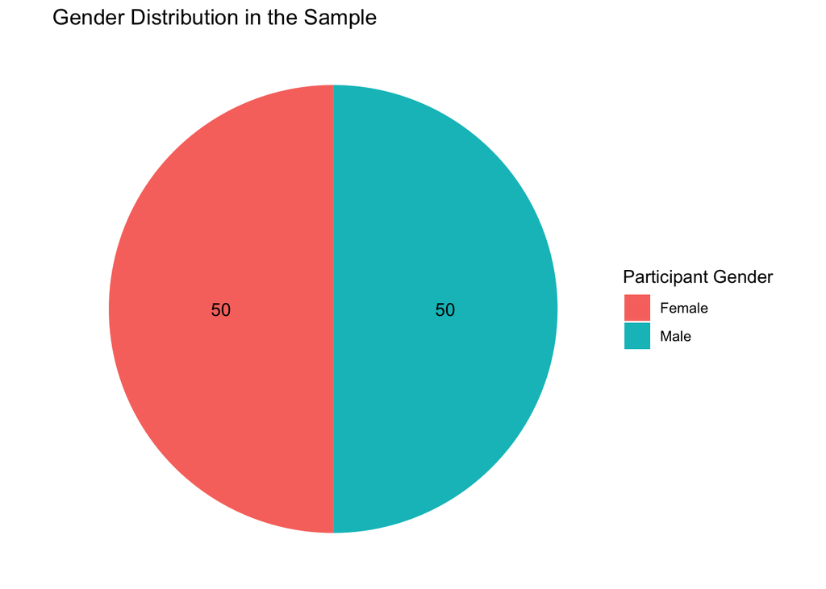

```r
pie.gender <- ggplot(df, aes(x = "", fill = as.factor(Gender), group = as.factor(Gender))) +
  geom_bar(position = "fill") +
  geom_text(stat = "count",
            aes(y = after_stat(..count..),
                label = after_stat(..count..)),
            position = position_fill(0.5)) +
  coord_polar(theta = "y") +
  theme_void() +
  labs(title = "Gender Distribution in the Sample", fill = "Participant Gender")
pie.gender
```

#Interpretation The sample is evenly split: 50% Male, 50% Female which means our analysis won’t be biased toward one gender.

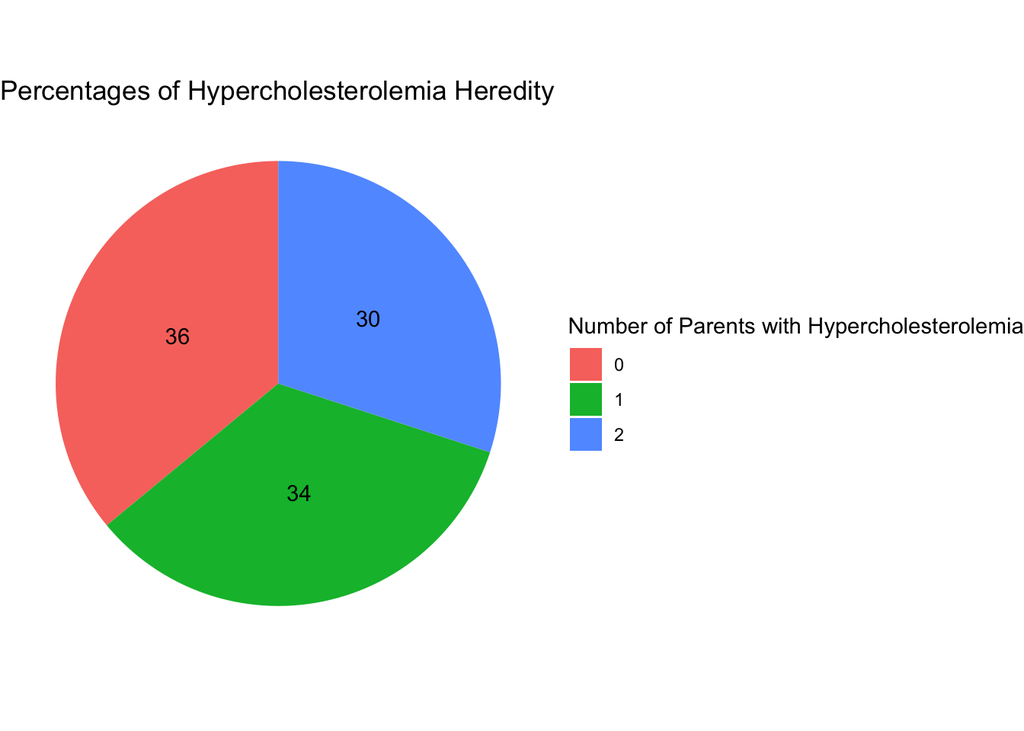

```r
pie.heredity<-ggplot(df, aes(x="",fill=as.factor(Heredity),group=as.factor(Heredity))) +
  geom_bar(position="fill") +
  geom_text(stat='count',
            aes(y=after_stat(..count..),label=after_stat(..count..)),
            position=position_fill(0.5)) +
  coord_polar(theta="y") +
  theme_void()+
  labs(title="Percentages of Hypercholesterolemia Heredity",fill="Number of Parents with Hypercholesterolemia")
pie.heredity
```

#Interpretation Around 36% of participants have no family history of hypercholesterolemia, meaning neither parent was affected. About 34% reported that only one parent had high cholesterol, while the remaining 30% stated that both parents had a history of hypercholesterolemia. These data allows us to explore how genetic background might influence cholesterol levels, without having one group dominate the data. It also gives us a good foundation to assess whether hereditary factors play a significant role in predicting total cholesterol in comparison to lifestyle variables like diet or exercise.

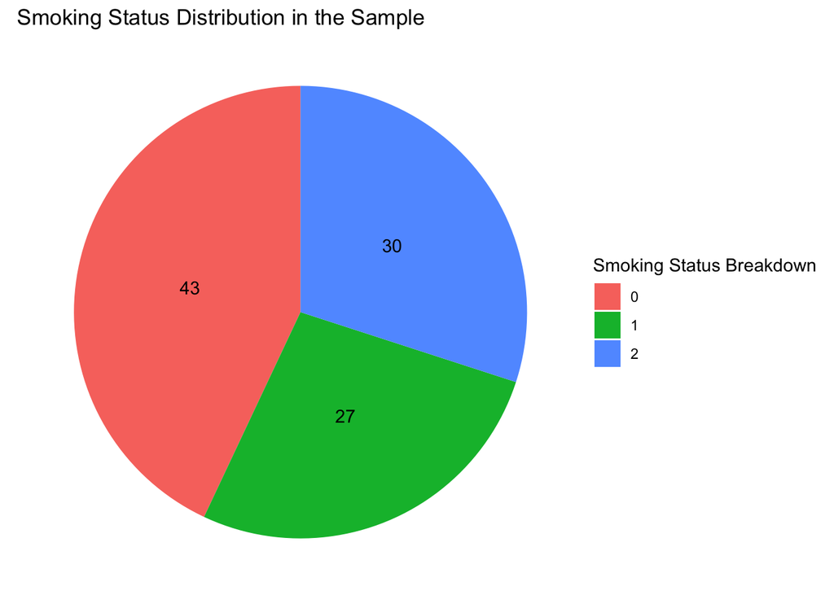

```r
pie.smoke <- ggplot(df, aes(x = "", fill = as.factor(Smoke), group = as.factor(Smoke))) +
  geom_bar(position = "fill") +
  geom_text(stat = "count",
            aes(y = after_stat(..count..),
                label = after_stat(..count..)),
            position = position_fill(0.5)) +
  coord_polar(theta = "y") +
  theme_void() +
  labs(title = "Smoking Status Distribution in the Sample",
       fill = "Smoking Status Breakdown")
pie.smoke
```

#Interpretation participants are categorized into nonsmokers which is about 43%, light smokers which is about 27%, and heavy smokers which is about 30%, which provides a wide range of smoking exposure levels. This variation is important because it allows us to examine whether different levels of tobacco use are associated with changes in total cholesterol.

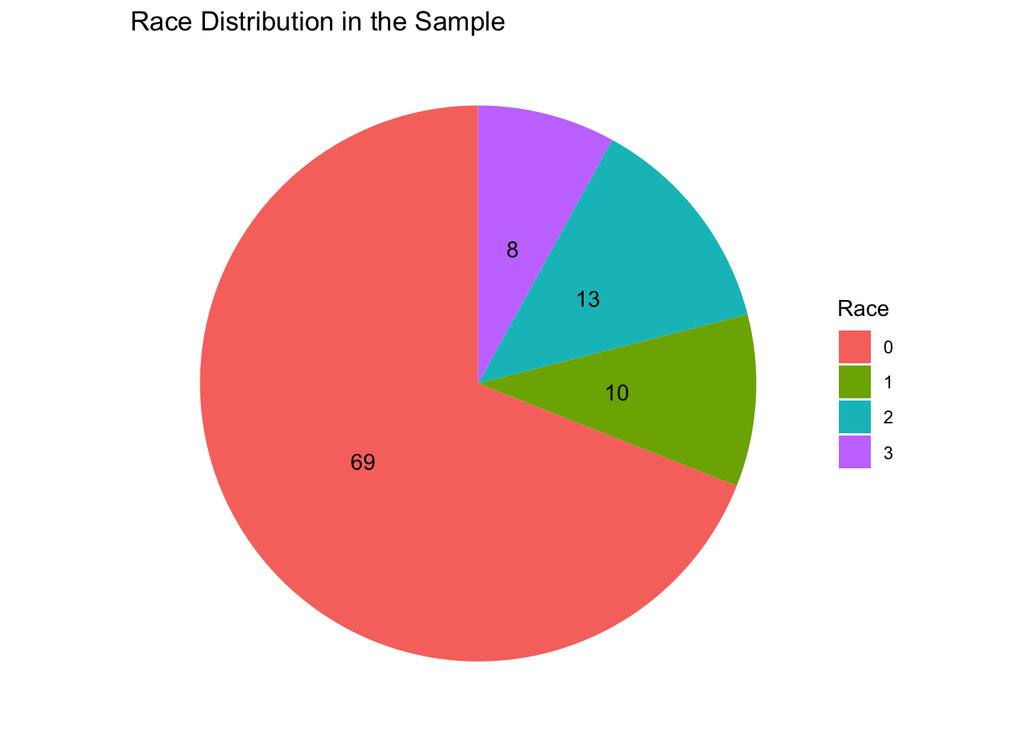

```r
pie.race <- ggplot(df, aes(x = "", fill = as.factor(Race), group = as.factor(Race))) +
  geom_bar(position = "fill") +
  geom_text(stat = "count",
            aes(y = after_stat(..count..),
                label = after_stat(..count..)),
            position = position_fill(0.5)) +
  coord_polar(theta = "y") +
  theme_void() +
  labs(title = "Race Distribution in the Sample",
       fill = "Race")
pie.race
```

#Interpretation the dataset includes participants from a few different racial backgrounds, but most of them about 69% are White. The rest of the sample includes 13% Black, 10% Hispanic, and 8% Asian individuals. While it’s good that there’s some diversity, the distribution is not fully balanced. Because most participants are White, any patterns or conclusions we find might mostly reflect that group.

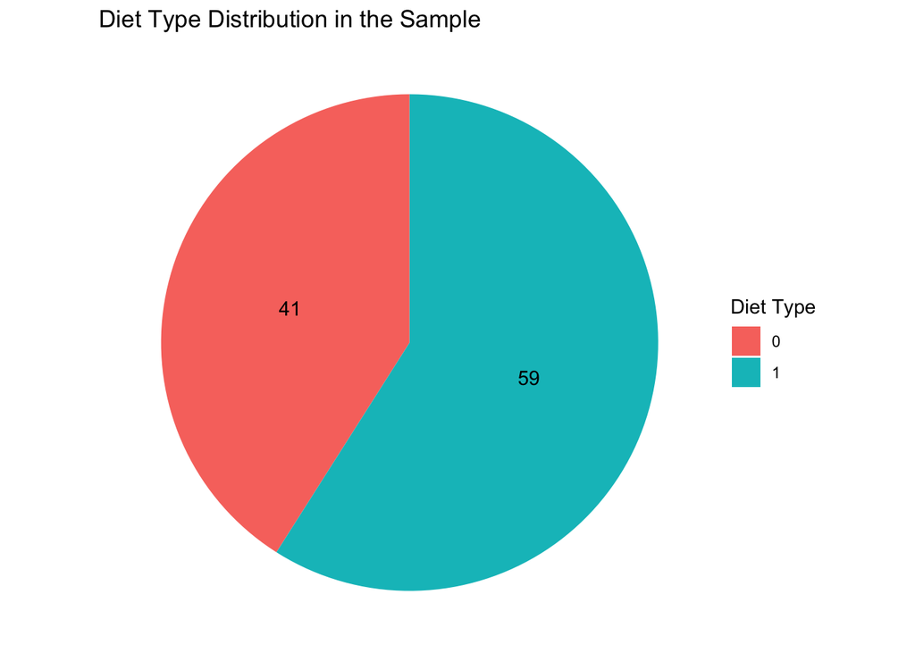

```r
pie.diet <- ggplot(df, aes(x = "", fill = as.factor(Diet), group = as.factor(Diet))) +
  geom_bar(position = "fill") +
  geom_text(stat = "count",
            aes(y = after_stat(..count..),
                label = after_stat(..count..)),
            position = position_fill(0.5)) +
  coord_polar(theta = "y") +
  theme_void() +
  labs(title = "Diet Type Distribution in the Sample",
       fill = "Diet Type")
pie.diet
```

#Interpretation About 59% reported having an unhealthy diet, while 41% said they follow a healthy diet. This data helps set the stage for analyzing whether diet quality is connected to cholesterol levels in the body.Since both diet types are well represented, we’ll be able to explore whether people with a healthier diet tend to have better cholesterol outcomes compared to those with poor eating habits.

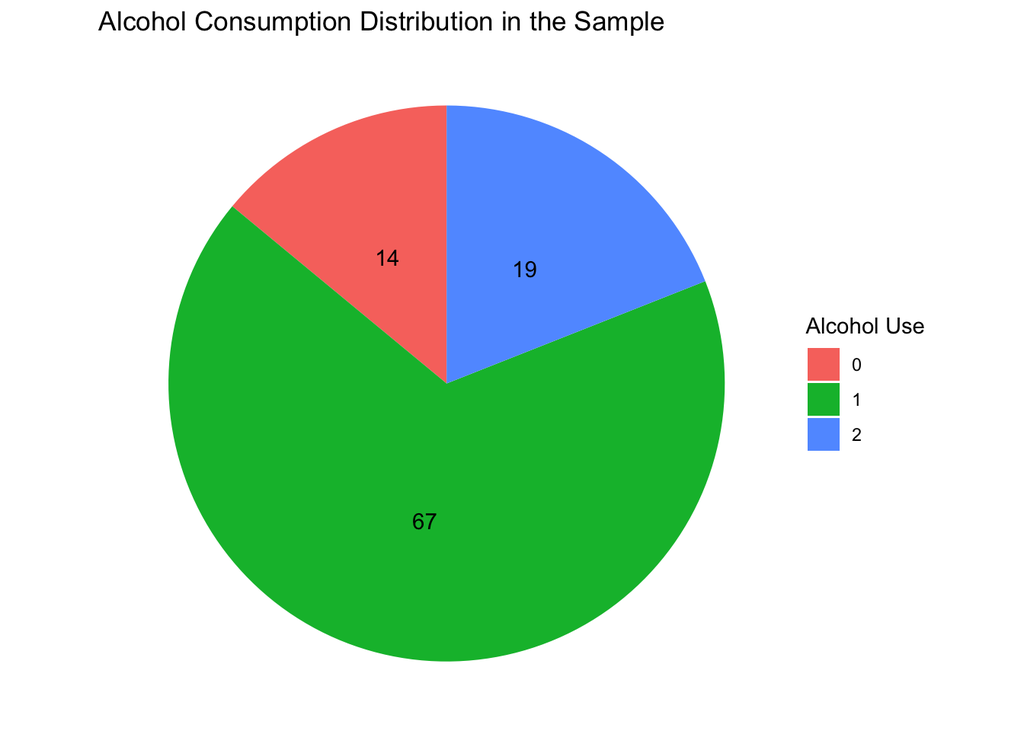

```r
pie.alcohol <- ggplot(df, aes(x = "", fill = as.factor(Alcohol), group = as.factor(Alcohol))) +
  geom_bar(position = "fill") +
  geom_text(stat = "count",
            aes(y = after_stat(..count..),
                label = after_stat(..count..)),
            position = position_fill(0.5)) +
  coord_polar(theta = "y") +
  theme_void() +
  labs(title = "Alcohol Consumption Distribution in the Sample",
       fill = "Alcohol Use")

pie.alcohol
```

#Interpretation According to the chart, most participants in the dataset, about 67%, are social drinkers, while 19% reported heavy alcohol use, and only 14% reported no alcohol consumption at all.the sample includes all three types of drinking behaviors, we’ll be able to observe if and how drinking habits are related to heart health risks like high cholesterol.

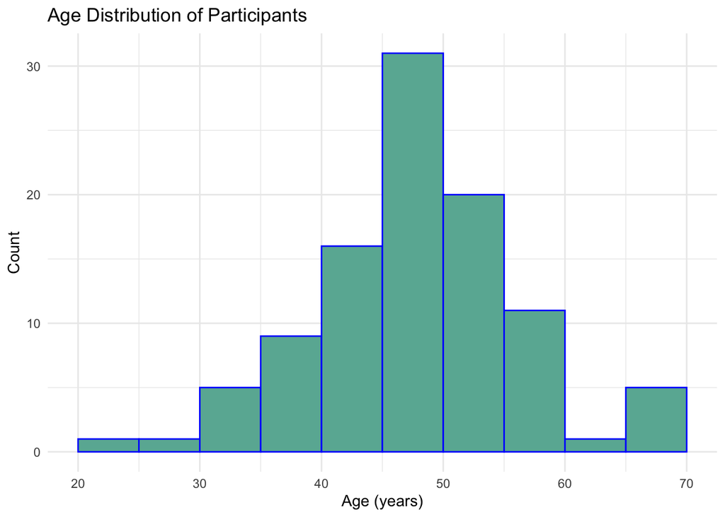

```r
histogram.age <- ggplot(df, aes(x = Age)) +
  geom_histogram(binwidth = 5, fill = "#69b3a2", color = "blue", boundary = 0) +
  labs(title = "Age Distribution of Participants",
       x = "Age (years)",
       y = "Count") +
  theme_minimal()
histogram.age
```

#Interpretation The age distribution of participants shows that most individuals in the dataset fall within the 40 to 60 year range, with the highest concentration around the 45–50 mark. There are a few younger participants in their 20s and 30s, as well as some older individuals up to age 70, but the majority are middle-aged.Since, middle-aged individuals are more likely to experience health issues related to cholesterol, having this age group well represented in the dataset helps strengthen the relevance of our analysis.

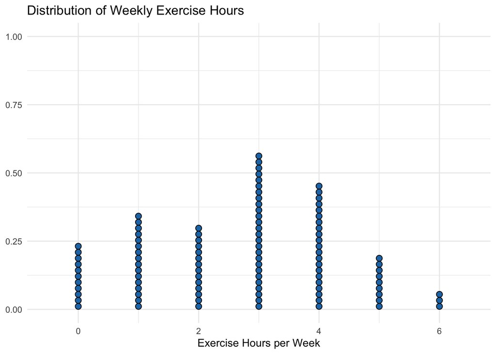

```r
dot.exercise <- ggplot(df, aes(x = Exercise)) +
  geom_dotplot(binwidth = 1, dotsize = 0.1, fill = "#1f78b4") +
  labs(title = "Distribution of Weekly Exercise Hours",
       x = "Exercise Hours per Week",
       y = NULL) +
  theme_minimal()
dot.exercise
```

#Interpretation Most participants engage in about 3 to 4 hours of physical activity per week. There are also several individuals who exercise less than 2 hours or not at all, and only a small number who exercise as much as 6 hours weekly.This data is useful because exercise is often linked to better heart health, and we can now explore whether those who exercise more tend to have lower cholesterol levels.

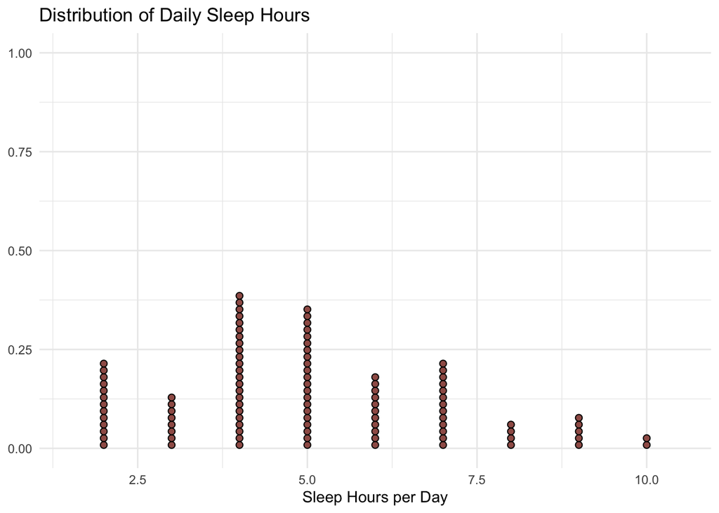

```r
dot.sleep <- ggplot(df, aes(x = Sleep)) +
  geom_dotplot(binwidth = 1, dotsize = 0.1, fill = "#a05d56") +
  labs(title = "Distribution of Daily Sleep Hours",
       x = "Sleep Hours per Day",
       y = NULL) +
  theme_minimal()
dot.sleep
```

#Interpretation The sleep pattern among participants shows that most people in the dataset sleep between 4 to 6 hours per day, with a few individuals getting as little as 2 hours or as much as 10 hours. This data shows that many participants seem to get less than the recommended 7–8 hours of sleep.Sleep also plays a major role in overall health, we can explore to see whether those who sleep more have healthier cholesterol levels

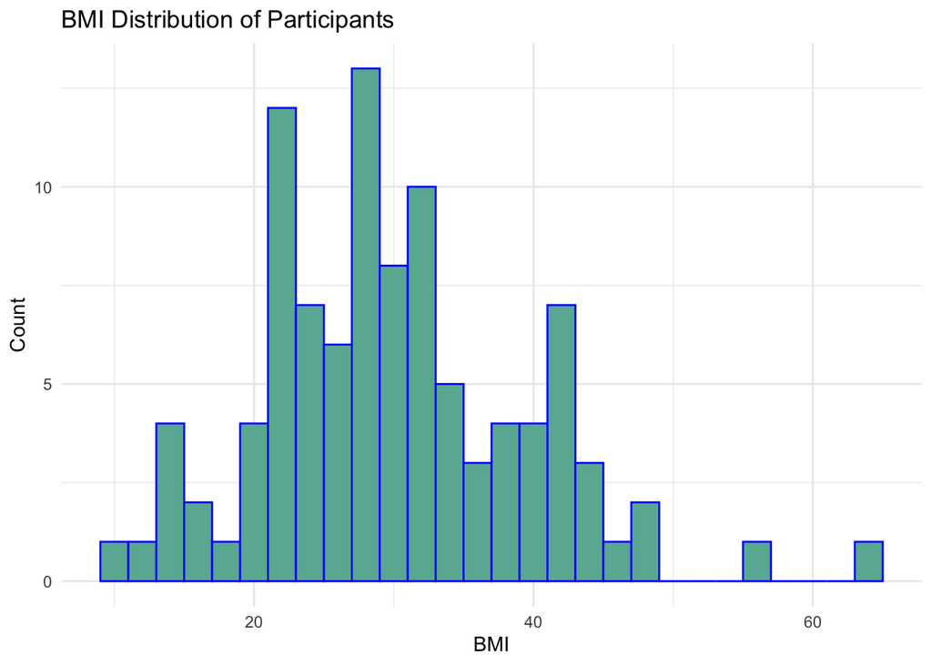

```r
histogram.bmi <- ggplot(df, aes(x = BMI)) +
  geom_histogram(binwidth = 2, fill = "#69b3a2", color = "blue") +
  labs(title = "BMI Distribution of Participants",
       x = "BMI",
       y = "Count") +
  theme_minimal()

histogram.bmi
```

#Interpretation The chart shows that most people in the data have a BMI between 20 and 40. This is where the bars are the tallest. Some people have a BMI a little less than 20 or more than 40, but not many. A few people have BMI that goes close to 60. This means there are many different body sizes in the group. Because BMI is important for health, we can check if people with higher BMI also have higher cholesterol.

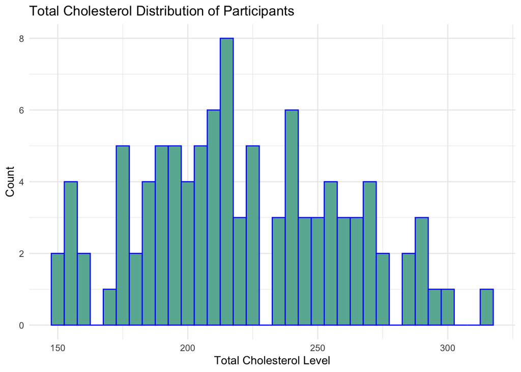

```r
histogram.chol <- ggplot(df, aes(x = Tot_Chol)) +
  geom_histogram(binwidth = 5, fill = "#69b3a2", color = "blue") +
  labs(title = "Total Cholesterol Distribution of Participants",
       x = "Total Cholesterol Level",
       y = "Count") +
  theme_minimal()
histogram.chol
```

## Correlations

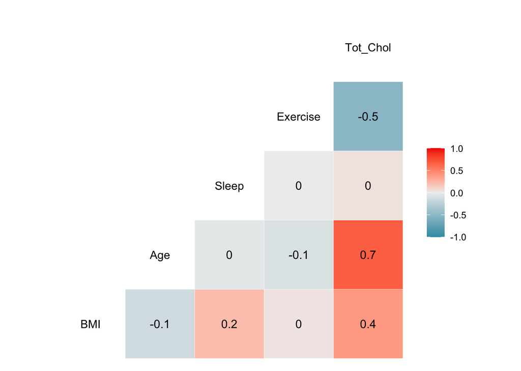

```r
# correlation matrix
library(GGally)
df$Gender <- as.factor(df$Gender)
df$Heredity <- as.factor(df$Heredity)
df$Smoke <- as.factor(df$Smoke)
df$Race <- as.factor(df$Race)
df$Diet <- as.factor(df$Diet)
df$Alcohol <- as.factor(df$Alcohol)
quantitative_vars <- df[, sapply(df, is.numeric)]
quantitative_vars <- quantitative_vars[c("BMI", "Age", "Sleep", "Exercise", "Tot_Chol")]
ggcorr(quantitative_vars, label = TRUE, label_size = 4)
```

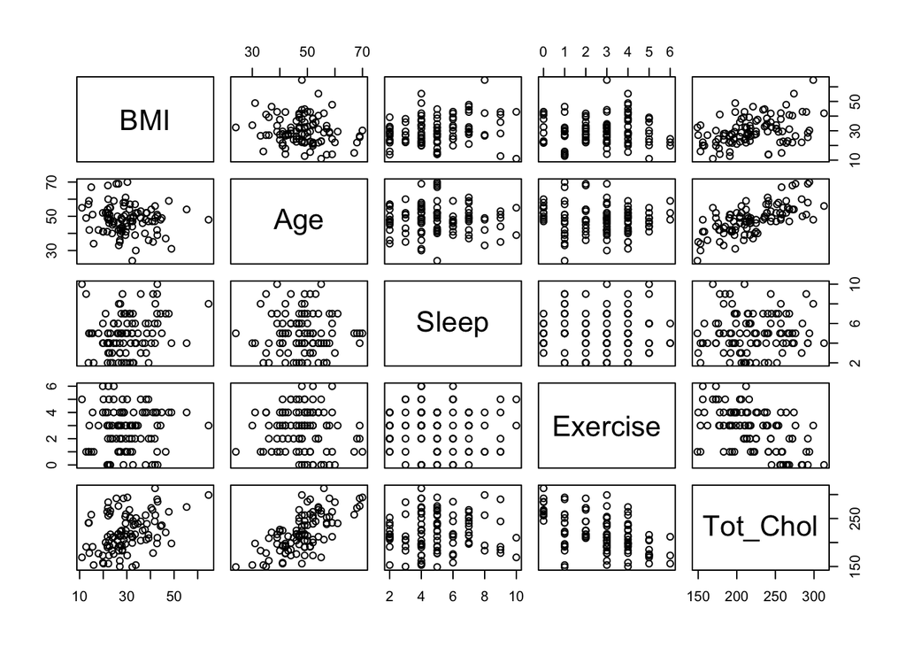

```r
plot(quantitative_vars)
```

### Interpretations Age has a strong positive relationship with cholesterol (0.7), meaning that as people get older, their cholesterol levels tend to be higher. BMI also has a moderate positive relationship (0.4), so people with higher BMI usually have higher cholesterol. On the other hand, exercise has a negative relationship with cholesterol (-0.5), which means that people who exercise more often tend to have lower cholesterol levels. Sleep shows no relationship (0), suggesting that how much someone sleeps does not affect their cholesterol in this dataset.

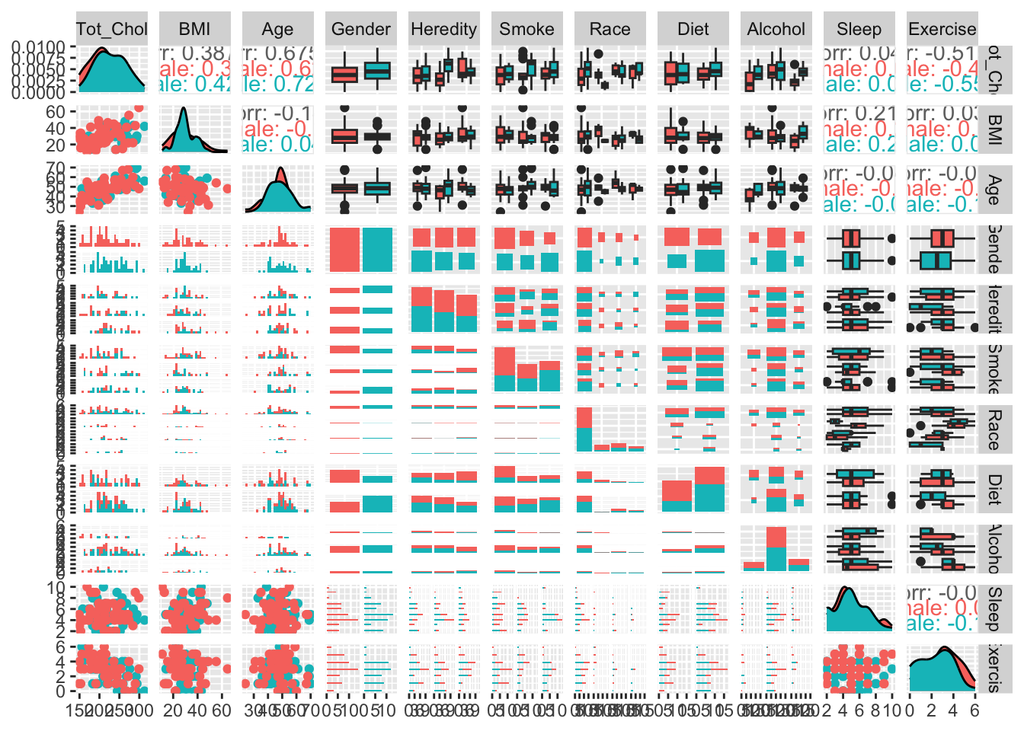

```r
# scatter plot thingy
ggpairs(df[, c("Tot_Chol", "BMI", "Age", "Gender", "Heredity",
               "Smoke", "Race", "Diet", "Alcohol", "Sleep", "Exercise")],
        aes(color = Gender))
```

### Interpretations

This chart shows how all the things in the data are connected. It uses red and blue to show two groups, like male and female. At the top, we can see numbers that tell us if two things go up or down together. For example, when BMI and age go up, cholesterol also goes up. So, older people or people with higher BMI may have higher cholesterol. Exercise is different-people who exercise more have lower cholesterol. Sleep does not change cholesterol much. The chart also shows differences in cholesterol based on gender, smoking, race, diet, and alcohol. This helps us understand what things might change a person’s cholesterol level.

## Recode Categorical Variables

```r
df2<-df%>%dplyr::select(Tot_Chol, BMI, Diet, Age, Sleep, Exercise)

# Gender where 1 is male
df2$Gender<-ifelse(df$Gender=="Male",1,0)
# H1 = 1 parent, H2 = 2 parents with Hypercholesterolemia
df2$H1<-ifelse(df$Heredity == 1, 1, 0)
df2$H2<-ifelse(df$Heredity == 2, 1, 0)
# Smoke where S1 is light smoker, and S2 is heavy
df2$S1<-ifelse(df$Smoke==1,1,0)
df2$S2<-ifelse(df$Smoke==2,1,0)
# Race where R1 is Hispanic, R2 is Black, and R3 is Asian
df2$R1<-ifelse(df$Race==1,1,0)
df2$R2<-ifelse(df$Race==2,1,0)
df2$R3<-ifelse(df$Race==3,1,0)
# Alcohol where A1 is social drinker, and A2 is heavy
df2$A1<-ifelse(df$Alcohol==1,1,0)
df2$A2<-ifelse(df$Alcohol==2,1,0)
df2
```

```
## # A tibble: 100 × 16
##    Tot_Chol   BMI Diet    Age Sleep Exercise Gender    H1    H2    S1    S2
##       <dbl> <dbl> <fct> <dbl> <dbl>    <dbl>  <dbl> <dbl> <dbl> <dbl> <dbl>
##  1      241  13.9 1        59     5        1      1     0     0     0     1
##  2      266  23.0 1        55     5        0      1     1     0     1     0
##  3      223  27.3 1        40     5        1      1     1     0     0     1
##  4      259  29.5 1        51     3        1      1     1     0     1     0
##  5      225  36.7 1        46     4        4      1     0     1     0     1
##  6      158  19.9 1        41     6        4      1     0     0     1     0
##  7      251  31.4 1        47     7        1      1     0     0     0     1
##  8      190  21.8 1        49     4        3      1     0     0     0     0
##  9      285  43.0 1        50     6        0      1     0     0     1     0
## 10      244  35.9 0        53     9        2      1     0     0     0     0
## # ℹ 90 more rows
## # ℹ 5 more variables: R1 <dbl>, R2 <dbl>, R3 <dbl>, A1 <dbl>, A2 <dbl>
```

## Full Model

```r
full_model <- lm(Tot_Chol ~., data = df2)
summary(full_model)
```

```
##
## Call:
## lm(formula = Tot_Chol ~ ., data = df2)
##
## Residuals:
##      Min       1Q   Median       3Q      Max
## -21.9718  -5.6354   0.4326   5.0267  23.8607
##
## Coefficients:
##             Estimate Std. Error t value Pr(>|t|)
## (Intercept)  27.9633     7.3569   3.801 0.000272 ***
## BMI           2.0595     0.1013  20.324  < 2e-16 ***
## Diet1        -0.8534     2.0667  -0.413 0.680725
## Age           3.0983     0.1146  27.041  < 2e-16 ***
## Sleep        -0.4817     0.4805  -1.002 0.319027
## Exercise    -11.8937     0.6632 -17.933  < 2e-16 ***
## Gender        2.9995     1.9958   1.503 0.136607
## H1            7.8396     2.2162   3.537 0.000661 ***
## H2           13.7085     2.3871   5.743 1.45e-07 ***
## S1            5.2128     2.4365   2.139 0.035302 *
## S2            8.0521     2.3669   3.402 0.001027 **
## R1            0.4127     3.3090   0.125 0.901040
## R2            1.2368     3.0321   0.408 0.684381
## R3           -0.8498     3.5509  -0.239 0.811433
## A1            5.1611     3.0322   1.702 0.092438 .
## A2            4.2082     3.6506   1.153 0.252293
## ---
## Signif. codes:  0 '***' 0.001 '**' 0.01 '*' 0.05 '.' 0.1 ' ' 1
##
## Residual standard error: 8.889 on 84 degrees of freedom
## Multiple R-squared:  0.956,  Adjusted R-squared:  0.9482
## F-statistic: 121.7 on 15 and 84 DF,  p-value: < 2.2e-16
```

```r
par(mfrow = c(3, 2))
# Create a residual plot
plot(full_model)
qqnorm(full_model$residuals)
qqline(full_model$residuals)
ad.test(full_model$residuals)
```

```
##
##  Anderson-Darling normality test
##
## data:  full_model$residuals
## A = 0.24559, p-value = 0.7529
```

```r
vif(full_model)
```

```
##      BMI     Diet      Age    Sleep Exercise   Gender       H1       H2
## 1.178737 1.307718 1.199962 1.171746 1.399601 1.260326 1.394959 1.514533
##       S1       S2       R1       R2       R3       A1       A2
## 1.480971 1.489040 1.247202 1.316042 1.174536 2.572847 2.595884
```

[figure not shown]

### Interpretations

Assumptions for a linear model are met as the residuals appear to have equal variance and there is not sufficient evidence to show they are not normal (Anderson-Darling p-value=0.7529). The full model is too expensive as it uses 10+ variables, so we will conduct best subsets. Appears to be no problems with co-linearity.

## Best Subsets

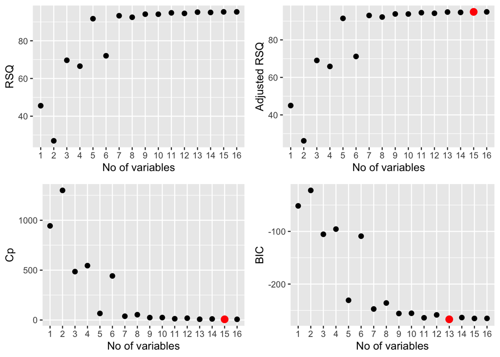

```r
subsets <- regsubsets(Tot_Chol ~., data = df2, nbest = 2)
subset.summary<-summary(subsets)

RSQ<-round(subset.summary$rsq * 100, digits=2)
ADJ_RSQ<-round(subset.summary$adjr2 * 100, digits=2)
CP<-round(subset.summary$cp, digits=2)
BIC<-round(subset.summary$bic, digits=2)
b<-subset.summary$outmat
Nvar<-1:nrow(subset.summary$which)
a<-cbind(Nvar,b,RSQ,ADJ_RSQ,CP,BIC)
a<-as.data.frame(a)
a$Nvar<-as.numeric(a$Nvar)
a$RSQ<-as.numeric(a$RSQ)
a$ADJ_RSQ<-as.numeric(a$ADJ_RSQ)
a$CP<-as.numeric(a$CP)
a$BIC<-as.numeric(a$BIC)

p1<-ggplot(data = a, aes(x = as.factor(Nvar), y = RSQ))+
  geom_point(color="black", size=2) +ylab("RSQ") + xlab("No of variables")

p2<-ggplot(data = a, aes(x = as.factor(Nvar), y = ADJ_RSQ)) +
  geom_point(color="black", size=2) +ylab("Adjusted RSQ") + xlab("No of variables")+
  geom_point(data = a[which.max(a$ADJ_RSQ), ], color="red",
             size=3)

p3<-ggplot(data = a, aes(x = as.factor(Nvar), y = CP)) +
  geom_point(color="black", size=2) +ylab("Cp") + xlab("No of variables")+
  geom_point(data = a[which.min(a$CP), ], color="red",
             size=3)

p4<-ggplot(data = a, aes(x = as.factor(Nvar), y = BIC)) +
  geom_point(color="black", size=2) +ylab("BIC") + xlab("No of variables")+
  geom_point(data = a[which.min(a$BIC), ], color="red",
             size=3)
grid.arrange(p1,p2,p3,p4,nrow=2)
```

```r
set.seed(123)
sample <- sample(c(TRUE, FALSE), nrow(df2), replace=TRUE, prob=c(0.7,0.3))
train  <- df2[sample, ]
test   <- df2[!sample, ]
train.mat <- model.matrix(Tot_Chol ~., data = train)

MSE <- rep(NA, 16)
for(i in 1:16){
  coefi <- coef(subsets, id = i)
  pred <- train.mat[ ,names(coefi)] %*% coefi
  MSE[i] <- mean((train$Tot_Chol - pred)^2, data=train)
}
MSE<-MSE
test.mat <- model.matrix(Tot_Chol ~., data = test)
MSPE <- rep(NA, 16)
for (i in 1:16) {
  coefi <- coef(subsets, id = i)
  pred <- test.mat[, names(coefi)] %*% coefi
  MSPE[i] <- mean((test$Tot_Chol - pred)^2)
}
e<-cbind(a,MSE,MSPE)
e
```

```
##          Nvar BMI Diet1 Age Sleep Exercise Gender H1 H2 S1 S2 R1 R2 R3 A1 A2
## 1  ( 1 )    1             *
## 1  ( 2 )    2                            *
## 2  ( 1 )    3   *         *
## 2  ( 2 )    4             *              *
## 3  ( 1 )    5   *         *              *
## 3  ( 2 )    6   *         *                     *
## 4  ( 1 )    7   *         *              *            *
## 4  ( 2 )    8   *         *              *                  *
## 5  ( 1 )    9   *         *              *            *     *
## 5  ( 2 )   10   *         *              *         *  *
## 6  ( 1 )   11   *         *              *         *  *     *
## 6  ( 2 )   12   *         *              *      *  *  *
## 7  ( 1 )   13   *         *              *         *  *  *  *
## 7  ( 2 )   14   *         *              *         *  *     *           *
```

[output cut: 19 more lines]

### Interpretations

Adjusted R^2 is very close in most of these models to mid-90’s which is good. However, the best models based on CP and BIC are models 13 and 15.

## Evaluate Selected Models

```r
model13<-lm(Tot_Chol~BMI+Age+Exercise+H1+H2+S1+S2,data=df2)
summary(model13)
```

```
##
## Call:
## lm(formula = Tot_Chol ~ BMI + Age + Exercise + H1 + H2 + S1 +
##     S2, data = df2)
##
## Residuals:
##      Min       1Q   Median       3Q      Max
## -22.5549  -5.0672  -0.1267   4.9596  26.3907
##
## Coefficients:
##              Estimate Std. Error t value Pr(>|t|)
## (Intercept)  28.11029    6.83899   4.110 8.57e-05 ***
## BMI           2.02335    0.09619  21.035  < 2e-16 ***
## Age           3.16802    0.10841  29.223  < 2e-16 ***
## Exercise    -11.99831    0.58089 -20.655  < 2e-16 ***
## H1            7.99527    2.15050   3.718 0.000345 ***
## H2           13.96387    2.25737   6.186 1.68e-08 ***
## S1            6.08772    2.27304   2.678 0.008766 **
## S2            9.59147    2.12922   4.505 1.95e-05 ***
## ---
## Signif. codes:  0 '***' 0.001 '**' 0.01 '*' 0.05 '.' 0.1 ' ' 1
##
## Residual standard error: 8.868 on 92 degrees of freedom
## Multiple R-squared:  0.952,  Adjusted R-squared:  0.9484
## F-statistic: 260.9 on 7 and 92 DF,  p-value: < 2.2e-16
```

```r
vif(model13)
```

```
##      BMI      Age Exercise       H1       H2       S1       S2
## 1.066944 1.079200 1.078563 1.319501 1.360601 1.294815 1.210508
```

```r
model15<-lm(Tot_Chol~BMI+Age+Exercise+Gender+H1+H2+S1+S2,data=df2)
summary(model15)
```

```
##
## Call:
## lm(formula = Tot_Chol ~ BMI + Age + Exercise + Gender + H1 +
##     H2 + S1 + S2, data = df2)
##
## Residuals:
##      Min       1Q   Median       3Q      Max
## -20.3738  -5.0472  -0.3733   5.3972  24.9483
##
## Coefficients:
##              Estimate Std. Error t value Pr(>|t|)
## (Intercept)  26.48211    6.84760   3.867 0.000206 ***
## BMI           2.01704    0.09538  21.148  < 2e-16 ***
## Age           3.16301    0.10745  29.436  < 2e-16 ***
## Exercise    -11.76129    0.59323 -19.826  < 2e-16 ***
## Gender        3.14948    1.91032   1.649 0.102665
## H1            8.48085    2.15096   3.943 0.000158 ***
## H2           14.41527    2.25328   6.397 6.71e-09 ***
## S1            5.60162    2.27133   2.466 0.015528 *
## S2            8.51688    2.20801   3.857 0.000214 ***
## ---
## Signif. codes:  0 '***' 0.001 '**' 0.01 '*' 0.05 '.' 0.1 ' ' 1
##
## Residual standard error: 8.787 on 91 degrees of freedom
## Multiple R-squared:  0.9534, Adjusted R-squared:  0.9493
## F-statistic: 232.9 on 8 and 91 DF,  p-value: < 2.2e-16
```

```r
vif(model15)
```

```
##      BMI      Age Exercise   Gender       H1       H2       S1       S2
## 1.068665 1.080064 1.145861 1.181669 1.344715 1.380991 1.317008 1.326063
```

### Interpretations

There appear to be no problems with VIF for either model. Due to lower MSPE, we will choose model 15.

## Stepwise Regression

```r
null_model <- lm(Tot_Chol ~ 1, data = df2)

step_model <- step(full_model, direction = "both",
                   scope = list(lower = null_model, upper = full_model),
                   trace = 1)
```

```
## Start:  AIC=451.52
## Tot_Chol ~ BMI + Diet + Age + Sleep + Exercise + Gender + H1 +
##     H2 + S1 + S2 + R1 + R2 + R3 + A1 + A2
##
##            Df Sum of Sq   RSS    AIC
## - R1        1         1  6638 449.54
## - R3        1         5  6641 449.59
## - R2        1        13  6650 449.72
## - Diet      1        13  6650 449.73
## - Sleep     1        79  6716 450.71
## - A2        1       105  6742 451.09
## <none>                   6637 451.52
## - Gender    1       178  6815 452.18
## - A1        1       229  6866 452.91
## - S1        1       362  6999 454.83
## - S2        1       914  7551 462.43
## - H1        1       989  7626 463.41
## - H2        1      2606  9243 482.64
## - Exercise  1     25408 32045 606.97
## - BMI       1     32637 39274 627.31
## - Age       1     57776 64413 676.79
##
## Step:  AIC=449.54
## Tot_Chol ~ BMI + Diet + Age + Sleep + Exercise + Gender + H1 +
##     H2 + S1 + S2 + R2 + R3 + A1 + A2
##
##            Df Sum of Sq   RSS    AIC
## - R3        1         4  6643 447.61
## - R2        1        13  6651 447.73
## - Diet      1        16  6654 447.78
## - Sleep     1        79  6717 448.72
## - A2        1       104  6742 449.10
## <none>                   6638 449.54
## - Gender    1       177  6816 450.18
## - A1        1       228  6866 450.92
## + R1        1         1  6637 451.52
## - S1        1       364  7002 452.88
## - S2        1       928  7566 460.63
## - H1        1       989  7627 461.42
## - H2        1      2611  9249 480.71
```

[output cut: 98 more lines]

```
## - A1        1       184  7026 443.22
## - Gender    1       191  7033 443.33
## + A2        1        80  6763 443.40
## + Sleep     1        75  6767 443.47
## + R2        1        36  6806 444.04
## + Diet      1         2  6841 444.55
## + R1        1         1  6841 444.55
## + R3        1         0  6842 444.57
## - S1        1       374  7216 445.89
## - S2        1      1075  7917 455.16
## - H1        1      1121  7963 455.74
## - H2        1      3122  9964 478.15
## - Exercise  1     29258 36100 606.89
## - BMI       1     34532 41375 620.53
## - Age       1     62684 69526 672.43
```

```r
summary(step_model)
```

```
##
## Call:
## lm(formula = Tot_Chol ~ BMI + Age + Exercise + Gender + H1 +
##     H2 + S1 + S2 + A1, data = df2)
##
## Residuals:
##      Min       1Q   Median       3Q      Max
## -21.2351  -5.8250  -0.3317   4.8558  23.7464
##
## Coefficients:
##              Estimate Std. Error t value Pr(>|t|)
## (Intercept)  26.20277    6.79730   3.855 0.000217 ***
## BMI           2.01715    0.09465  21.313  < 2e-16 ***
## Age           3.12827    0.10894  28.715  < 2e-16 ***
## Exercise    -11.64346    0.59352 -19.618  < 2e-16 ***
## Gender        3.01070    1.89773   1.586 0.116139
## H1            8.22077    2.14096   3.840 0.000229 ***
## H2           14.33164    2.23659   6.408 6.62e-09 ***
## S1            5.05755    2.28087   2.217 0.029116 *
## S2            8.26288    2.19711   3.761 0.000301 ***
## A1            3.04831    1.96103   1.554 0.123588
## ---
## Signif. codes:  0 '***' 0.001 '**' 0.01 '*' 0.05 '.' 0.1 ' ' 1
##
## Residual standard error: 8.719 on 90 degrees of freedom
## Multiple R-squared:  0.9546, Adjusted R-squared:  0.9501
## F-statistic: 210.5 on 9 and 90 DF,  p-value: < 2.2e-16
```

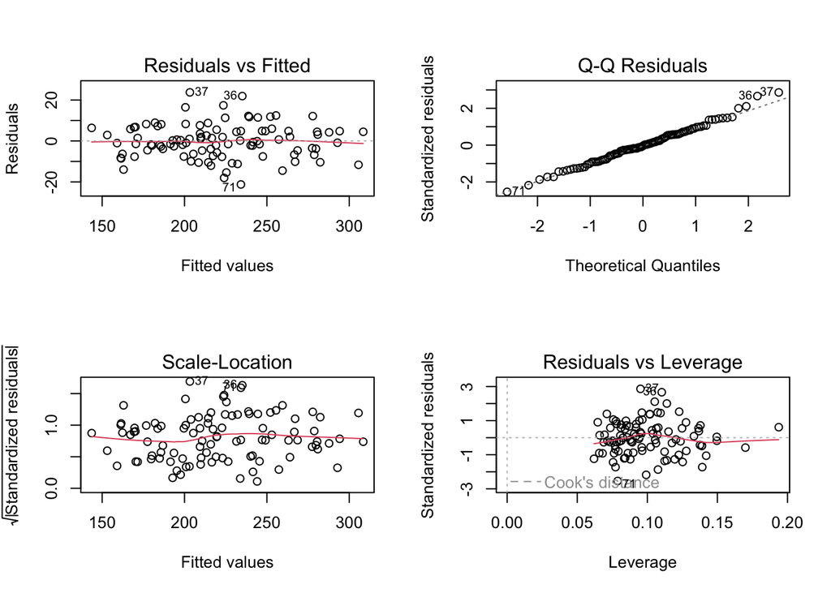

```r
par(mfrow = c(2, 2))
plot(step_model)
```

```r
anova(step_model, model15)
```

```
## Analysis of Variance Table
##
## Model 1: Tot_Chol ~ BMI + Age + Exercise + Gender + H1 + H2 + S1 + S2 +
##     A1
## Model 2: Tot_Chol ~ BMI + Age + Exercise + Gender + H1 + H2 + S1 + S2
##   Res.Df    RSS Df Sum of Sq      F Pr(>F)
## 1     90 6842.1
## 2     91 7025.8 -1    -183.7 2.4163 0.1236
```